# STA5075: Practical 12

## Part 3

## Calculate the average total pay out if you spin the reel 10/100/1000 times - i.e. one ‘play’ of the game is to spin the reel 10/100/1000 times, and you play the game 10000 times.

```r
total_payout <- function(spins) {
    spin <- sample(reel, size = spins, prob = probs, replace = TRUE)
    payout <- winnings[spin]
    cum_winnings <- sum(payout)
    return(cum_winnings)
}

set.seed(123)
plays.10 <- replicate(10000, total_payout(spins = 10))
mean(plays.10)
```

```
## [1] 19.37405
```

```r
plays.100 <- replicate(10000, total_payout(spins = 100))
mean(plays.100)
```

```
## [1] 193.6772
```

```r
plays.1000 <- replicate(10000, total_payout(spins = 1000))
mean(plays.1000)
```

```
## [1] 1939.659
```

3.1 Graphically display the average total pay out after 10/100/1000 plays of the game by means of histograms and box and whisker plots.

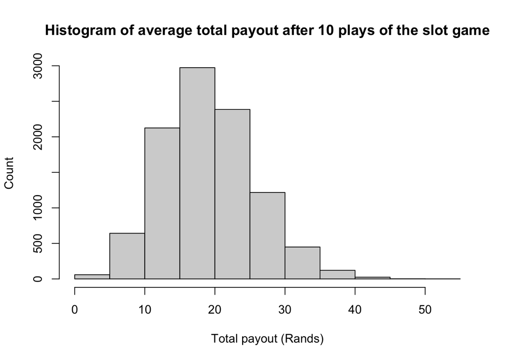

```r
# 10 Plays

# Histogram
hist(plays.10,
     main = "Histogram of average total payout after 10 plays of the slot game",
     xlab = "Total payout (Rands)",
     ylab = "Count")
```

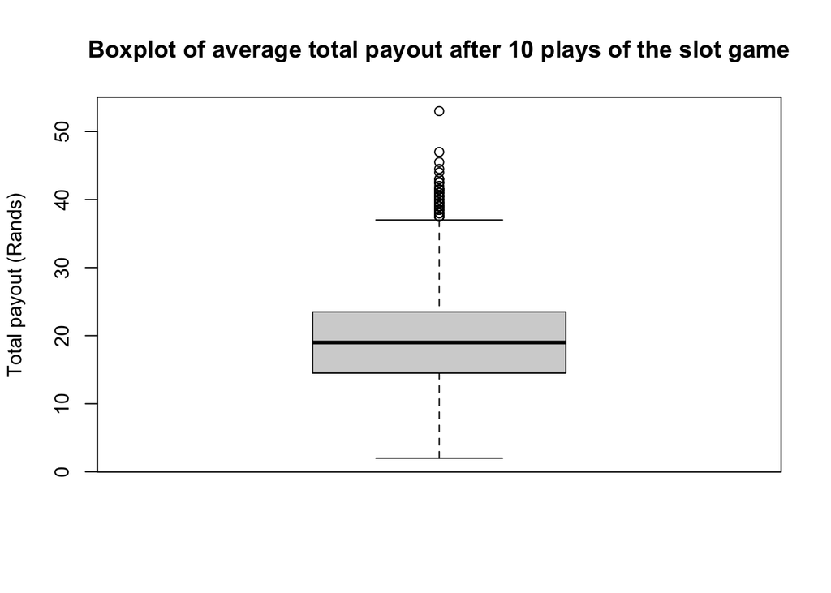

```r
# Boxplot
boxplot(plays.10,
        main = "Boxplot of average total payout after 10 plays of the slot game",
        ylab = "Total payout (Rands)")
```

3.2 Describe the distribution of the average total pay out pay out for each case by calculating relevant summary statistics. Submit all parts in one Rmarkdown file, along with the html output of the markdown file.